# R模型可视化

[宋骁](https://xsong.ltd)

[figure not shown]

模型可视化是应用统计学的重要内容。任何模型都离不开结果的可视化。所谓*模型*，不过是将一堆散点简化为一条线。结果的可视化需要预测值。Hadley Wickham的`modelr`包提供了重要的用于预测的函数。预测的结果可以直接被`ggplot2`使用并画图。

```r
library(dplyr)
library(tidyr)
library(ggplot2)
library(modelr)
library(haven)
library(easyGgplot2)
```

# 1 基础回归

`hatdt`为作者个人整理的[中国家庭追踪调查](http://www.isss.pku.edu.cn/cfps/index.htm)(CFPS)收入数据[^1]。

```r
hatdt <- hatdt %>%
  filter(type=='个人收入（元）') %>%
  drop_na(agem,inc,fswt_nat)

set.seed(20191001)
sample <- sample(1:nrow(hatdt),600,replace = F)
sampled <- hatdt[sample,]

plota <- ggplot(hatdt,aes(agem,inc,weight=fswt_nat)) +
  geom_jitter(data=sampled,height=550,width=5,
              size =1.5,alpha=1/3) +
  geom_smooth(span =10,size=1) +
  geom_smooth(method='lm',size=1,color='red') +
  ylim(0, 20000) +
  labs(x = "年龄",y = "人民币(元）") +
  theme_bw()

plotb <- ggplot() +
  geom_jitter(data=sampled,aes(agem,inc),
              height=550,width=5,size =1.5,alpha=1/3) +
  geom_quantile(data=hatdt,
  aes(agem,inc,weight=fswt_nat),
  size=1,color='red')+
  ylim(0, 20000) +
  labs(x = "年龄",y = "人民币(元）") +
  theme_bw()
```

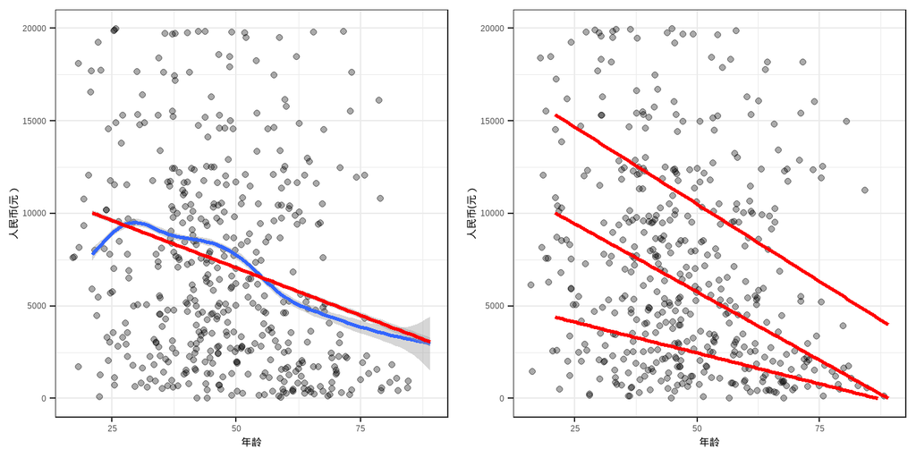

Figure 1.1: 个人收入与年龄。左图：红线为线性回归模型。蓝色曲线为非参数回归。右图：三条线分别是分位数回归。高收入者收入随年龄下降的速度快于低收入者。可将中位数回归与左图线性回归相比较，观测其中的差异。

```r
ggplot2.multiplot(plota,plotb,cols=2)
```

# 2 多项式回归

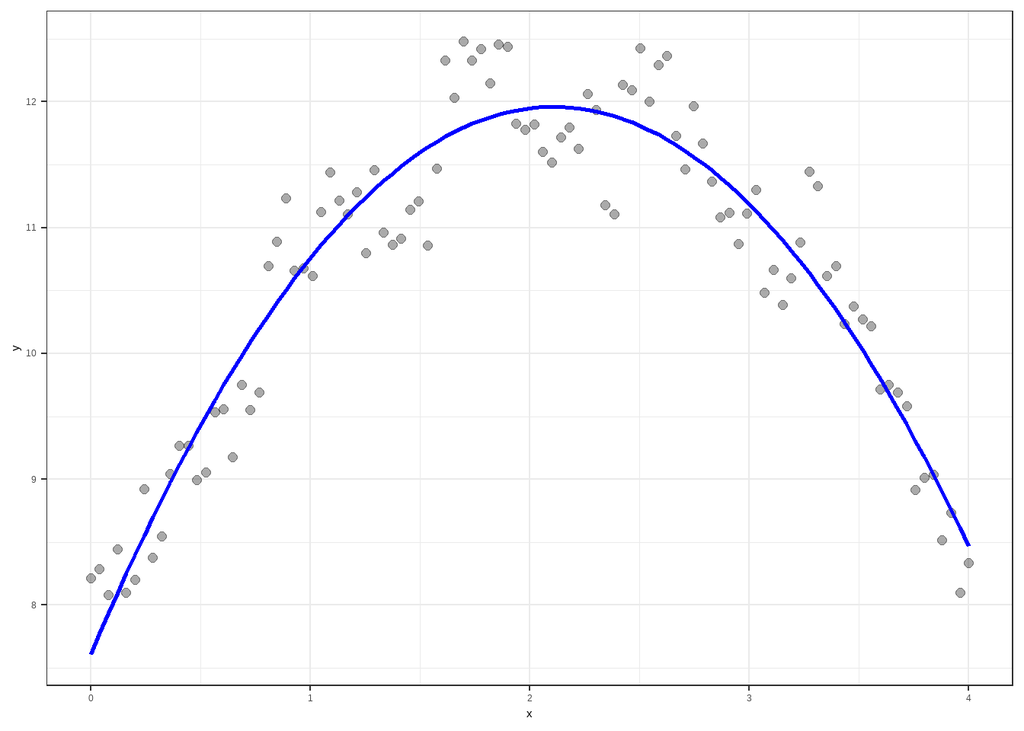

Figure 2.1: 对一个模拟数据进行二次项回归。

```r
set.seed(2019)
x <- seq(0,4,length=100)
y <- -x^2 + 3*x + jitter(rep(5:9,each =20),2) +3
df <- data.frame(x,y)

reg <- lm(y ~ x + I(x^2),df)

grid <- df %>%
data_grid(x) %>%
gather_predictions(reg)

ggplot(df,aes(x,y))+
  geom_point(size =2,alpha=1/3)+
  geom_line(data=grid,aes(x,pred),size=1,color='blue')+
  theme_bw()
```

下面使用多项式回归拟合CFPS数据:

$$y = {\alpha _0} + {\alpha _1}{x_1} + x_1^2$$
$$y = {\alpha _0} + {\alpha _1}{x_1} + x_1^2 + x_1^3$$

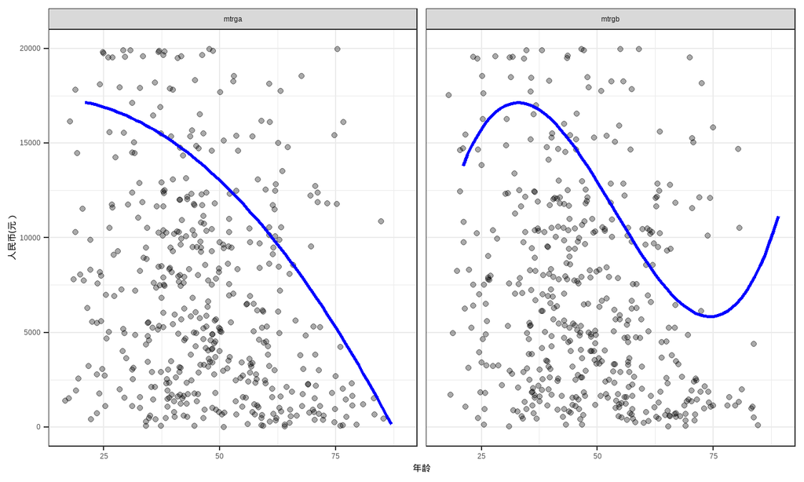

Figure 2.2: 分别对CFPS数据进行二次项和三次项回归。三次项导致了过拟合。

```r
mtrga <- lm(inc~agem+I(agem^2),hatdt)
mtrgb <- lm(inc~agem+I(agem^2)+I(agem^3),hatdt)

grid <- hatdt %>%
data_grid(agem) %>%
gather_predictions(mtrga,mtrgb)

ggplot() +
  geom_jitter(data=sampled,aes(agem,inc),
              height=550,width=5,size =1.5,alpha=1/3) +
  geom_line(data=grid,aes(agem,pred),
            size=1,color='blue')+
  facet_wrap(~model) +
  ylim(0, 20000) +
  labs(x = "年龄",y = "人民币(元）") +
  theme_bw()
```

# 3 交互项

交互项是计量经济学和应用统计学常用的机制分析技术。公式如下：

$$y = {\alpha _0} + {\alpha _1}{x_1} + {\alpha _2}{x_2} + {\alpha _3}{x_1}{x_2}$$

下面使用R自带数据，1994年加拿大劳动与收入动态调查(SLID)。详细信息请在R中输入`?carData::SLID`查看。

## 3.1 分类变量与连续变量交互

因变量为收入。自变量为教育年限(年)和使用的语言(英语、法语、其他)。下面分别展示了没有交互项和有交互项的模型。

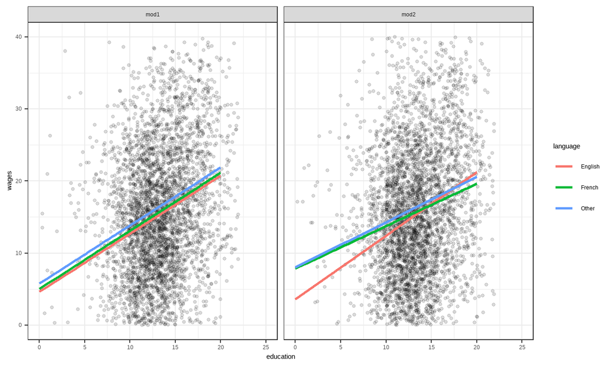

```r
#?carData::SLID
data(SLID,package = 'carData')
SLID <- SLID %>% drop_na()

mod1 <- lm(wages ~ education + language,SLID)
mod2 <- lm(wages ~ education * language,SLID)

grid <- SLID %>%
data_grid(education,language) %>%
gather_predictions(mod1,mod2)

ggplot(SLID,aes(education,wages))+
  geom_jitter(size=1,width=2,height=10,alpha=1/7)+
  geom_line(data=grid,
            aes(education,pred,color=language),size=1)+
  facet_wrap(~model)+
  xlim(0,25)+ ylim(0,40)+
  theme_bw()
```

## 3.2 两个连续变量交互

对两个连续交互变量的可视化是一个难题。较好的解决办法是分箱。使用`modelr`的`seq_range`函数对其中一个连续变量进行分箱。

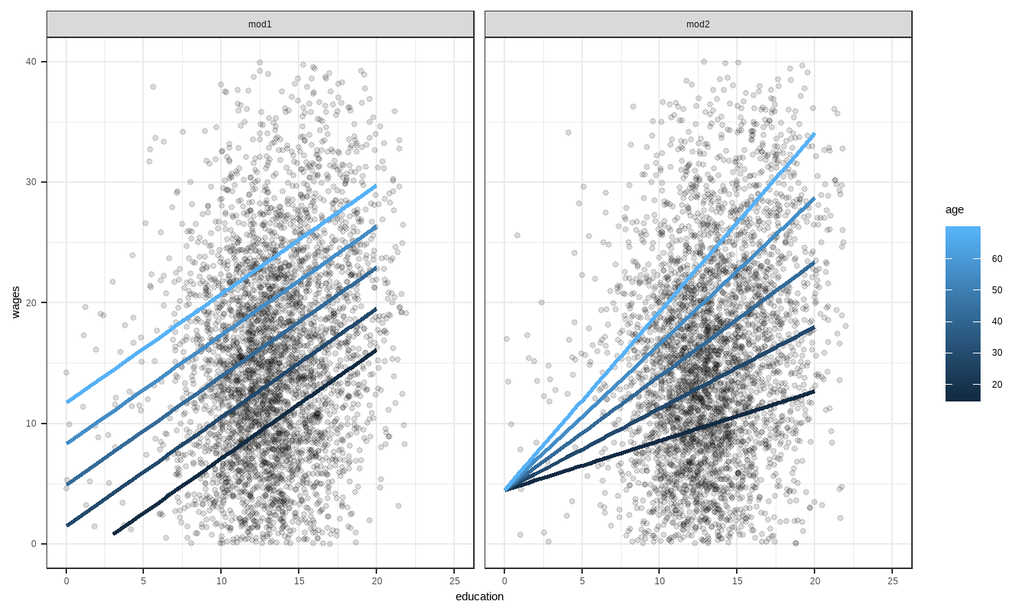

```r
mod1 <- lm(wages ~ education + age,SLID)
mod2 <- lm(wages ~ education * age,SLID)

grid <- SLID %>%
data_grid(education,age = seq_range(age, 5)) %>%
gather_predictions(mod1,mod2)

ggplot(SLID,aes(education,wages))+
  geom_jitter(size=1,width=2,height=10,alpha=1/7)+
  geom_line(data=grid,aes(education,pred,
                          color=age,group=age),size=1)+
  facet_wrap(~model)+
  xlim(0,25)+ ylim(0,40)+
  theme_bw()
```

[^1]: 可从[Github](https://github.com/ECSTA7Y/MaLearning/blob/master/aggregrate.csv)下载